# Business Potential for Macrame Based Products on Etsy

Victoriano Garza Sánchez

# Introduction

## Background

As never before people today can become self-employed and be more profitable then on a typical job, the Internet made this economy possible and there is place for all type of economic exchange thanks to this. But Over the years the offerings have increase and get noticed is sort of a pain and for this new startegies have to emerge in order to be reachable to buyers and to compete.

## Problem

There is no easy way to become selfemployed and many people are both, employed by day and self-employed by night only to get and extra cash (not usable to live out of it). But, what would it take to become really profitable (to be able to quit your job)? This is the answer this study aims to find.

So in order the give light on this regards a niche was selected and this is around macrame handmade products sold on a really famous ecommerce platform (for artist makers)

The main objective is to bring insights on whether or not an artist should invest time and money on the development of macrame products aswell as to give her more information on what would be the less risky path (and most lucrative one) to take in case there were a good opportunity in this niche.

## Iterest

This analysis would be helpful for those self-employed who sell their own products and want to make a living from her passion.

# Data acquisition and cleaning

## Data source

The source of the data was a famous ecommerce platform for artist that make and sell their own handmade stuff and in order to answer the main question, how well does macrame jewelry do on this ecommerce, sales data for macrame products was a must, so this data would need to have features like:

- Item price
- Item sales
- Item sales dates
- Item category (whithin macrame categories)
- Seller

Other useful features:

- Item favorers (people who save the product on their favorites)
- Seller macrame ratio over other type of products
- Country

Needless to say that the journey on this regards was not smooth mainly because this platform doesn’t provide an API for the really good stuff (it does have an API), so the solution here was to scrape the data and infer the previously mentioned features from the available features:

- Products
  - Date it was listed
  - Price
  - Country
  - Seller
  - Favorers
  - Bestseller (boolean)
  - Categories
  - Digital (guides to make macrame stuff)
  - Category (jewelry, material, decoration, other)
- Shops
  - Total items sold
  - Favorers
  - Rating
  - Year of seller registration
  - Listings
  - Listings by category

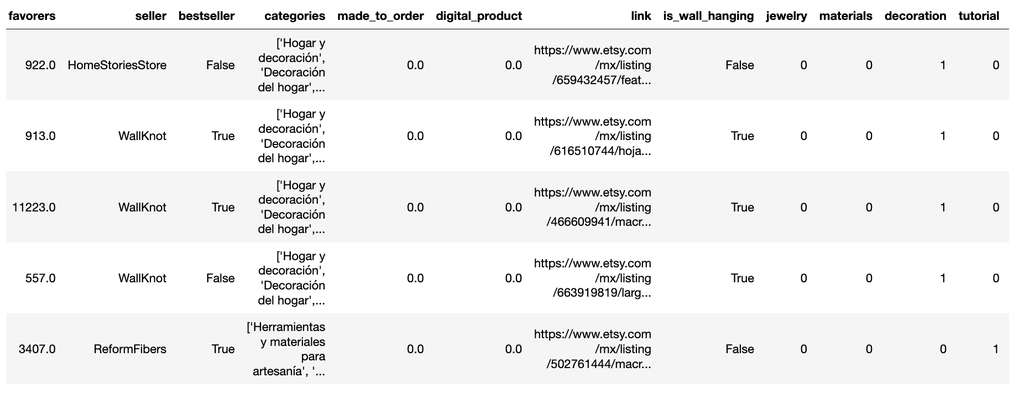

Product List Data Frame

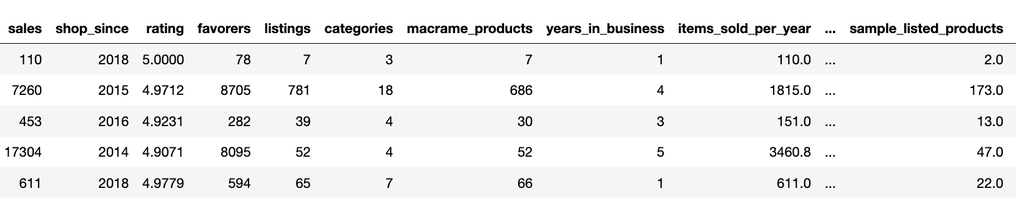

Shops Data Frame

## Data gathering

**BeautifulSoup** was use to scrape the available data, and some custom functions with regular expressions were used to complement this. The platform gave more then 400,000 results for the word macrame; there was no way I could grab all those listings (mainly because the requested are blocked after *n* tries) and make it in time for delivery so I decided to go for the population sample technique and randomly picking product links.

The data that was need it was not publicy available but there was public data that could be use to infer the need it information in order to make the analysis and for this I grab data for macrame products and on the other side data from shops (that sell the macrame products) were grab too.

After getting a decent number of products it was time to explore this data, find problems with it and build new columns for new features.

## Data cleaning

The good thing about extracting the data yourself and from one source is that you get what you need in the way you need it so data cleaning was not really an issue here so the only thing I had to work was the new datasets that had to be created based on the original ones.

# Methodology

A real problem here were the really extreme outliers, the spread and because of this the skewness (right skew).

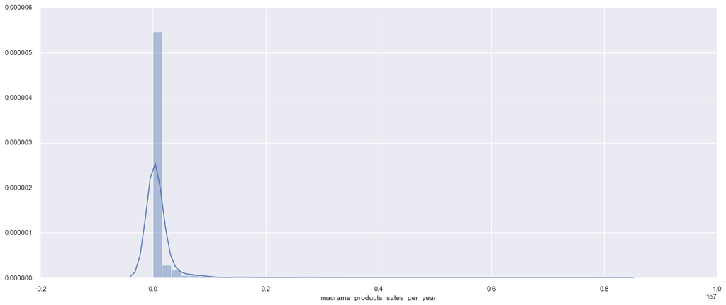

Data skewness

## Exploratory analysis

We now know that our data is not normally distributed and we have extreme outliers and for this I’m trying to figure out which machine learning strategy should be used, ofcourse is too soon for that at this point.

I decided to visualize some features because I knew this would give me some early insights.

The thing to notice from figure 1 (distribution plot) is the incredible force pulling sellers to zero sales, this means that is really difficult to make good sales (at list on this platform). Is like the gravity force pulling every object into it and only a really strong force can go against this and free itself; this is sort of what it looks like to be a profitable seller so in order to make a leaving of this you must applied a lot of force.

I guess this is no news (we know selling is difficult) but this is overwhelming (maybe I’m exaggerating a little bit here).

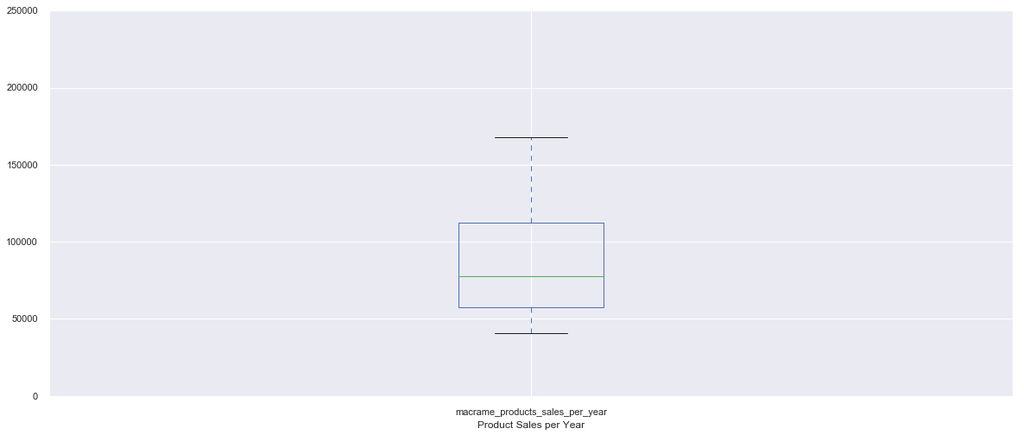

The good news is that is less probable to not make a sale but getting enough sales to live from these becomes harder.

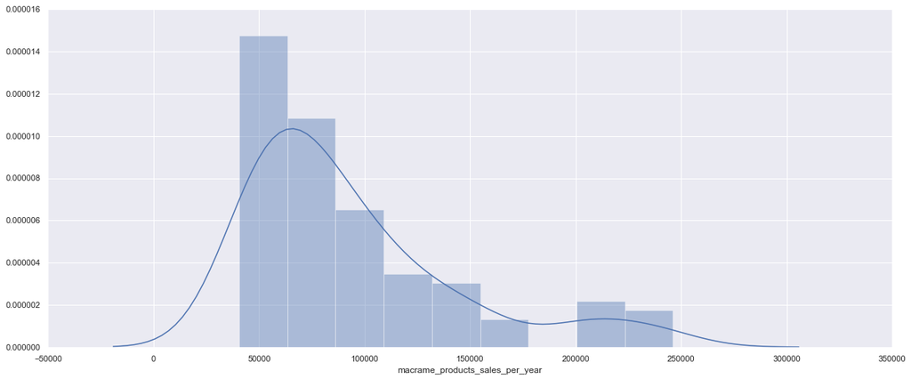

For this chart I norrow down the view by removing some sellers, the ones without a single sale and the ones with extremly good selling numbers. The force I talked prviously is more clear in the sense of how the tendecy is towards zero but after some factor happens the sellers can get out of this force and do pretty good; on a big picture (**Figure 3**) this good sellers are not normally distributed which is to be expected.

As I told previously there where no public data on product sales, but on the seller page there were information on their total sales, all their products listed and their prices and with those I got the product price mean and with their total sales number I got something better then nothing, an estimation of shopers sales. (I could have weight the price using each product favorers)

After the previous step I then got the proportion of macrame profits comparing the total products and the percentage of this products that were macrame.